# 01 - ggplot2 intro

## Histogram

Bar graph for a continuous variable

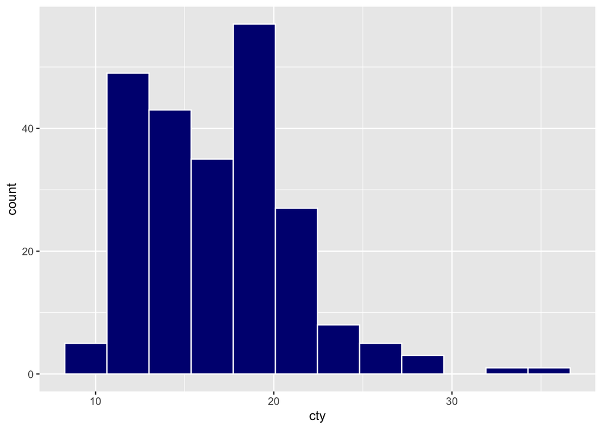

```r
ggplot(data = mpg,
       mapping = aes(x = cty)) +
  geom_histogram(bins = 12,
                 fill = "navy",
                 color = "white")
```

## Jitter plot

When the data has many similar observations, scatterplot can be misleading because it may have many overlapping points. One way to handle that is to make points more transparent.

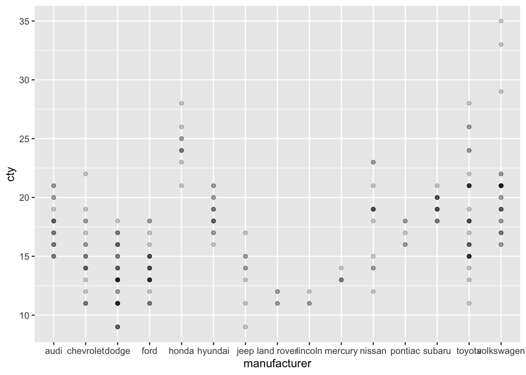

```r
ggplot(data = mpg,
       mapping = aes(x = manufacturer, y = cty)) +
  geom_point(alpha = 0.2)
```

Another option is to add some random noise to the points to create a jittering effect

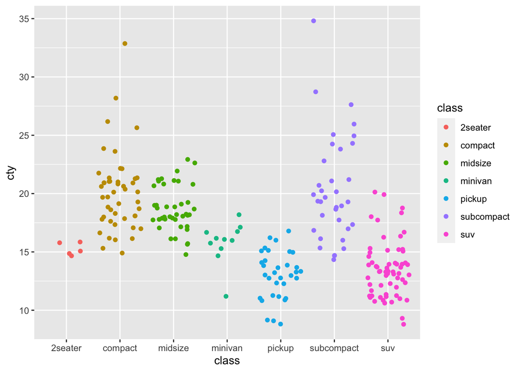

```r
set.seed(999)
ggplot(data = mpg,
       mapping = aes(x = class,
                     y = cty,
                     color = class)) +
  geom_jitter()
```

You can also add a violin plot to this. Violin plot shows you the distribution of the data subset.

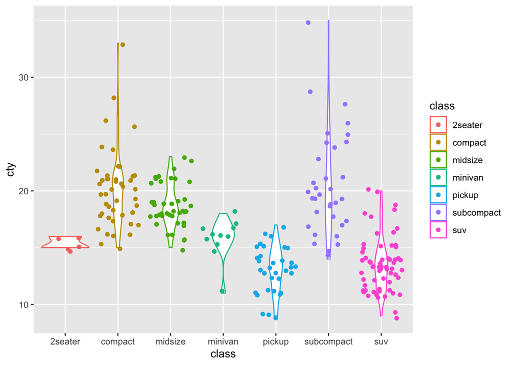

```r
set.seed(999)
ggplot(data = mpg,
       mapping = aes(x = class,
                     y = cty,
                     color = class)) +
  geom_violin() +
  geom_jitter()
```